# 1 Introduction

A potential well is a confined region of space where a particle's potential energy is lower than the surrounding area. Each discrete energy level of the particle in the well is in a bound state if it is smaller than the potential energy at the boundary. In contrast to classical mechanics, where particles can oscillate over a continuous range of energies, quantum mechanics restricts the energy levels of particles in a well to discrete values. The first energy level at which the confined particle is in equilibrium is called the ground state. Rarely, a particle may be able to tunnel through the borders and leave the well. Using numerical and iterative approaches to solve for their wavefunction and energy, this notebook investigates the behaviour of particles in bound states of a potential well, comparing the outcomes to analytical solutions when available.

### Global variables section

Below are a list of global variables which involve both univsersal constats of physics aswell as paramters which relate to the properties of the sytem being investigated.

```python
#importing modules
import numpy as np
import matplotlib.pyplot as plt
import pandas as pd
#!pip install pandas
import warnings
warnings.filterwarnings("ignore", category=FutureWarning)

# USEFULL constants: mass off electron (kg), hbar, electron charge (C),
q_electron = 1.602176634e-19
m_electron = 9.109383702e-31
h_bar = 1.054571817e-34

#Parameters for potential I (Infinite square well):

energy_values_I = np.linspace(0,30000,1500) # Array of 30000 energy values in eV
energy_array_I = np.linspace(0,30000*q_electron,1500) # Array of energies in joules
frame_levels_I = np.linspace(1,28,28) # The number of energy levels that are calculated

#Parameters for potential II (Harmonic potential/ Finite square well / Double well):

energy_values_II = np.linspace(0,1500,350) # Array of 1000
energy_array_II = np.linspace(0,1500*q_electron,350)# Array of energies
frame_levels_II = np.linspace(0,3,4)#  number of energy levels


# parameters for numerical integration
N = 2000
half_width = 5e-11  #x10^11
x_start = -half_width
x_end = half_width
h_step = (abs(x_start)+abs(x_end))/N
x_points = np.arange(x_start, x_end, h_step) # Array of x points to iterate over
#ground state initialisation
wave_func_initial = 0 # Initial wave_function value
phi_initial = 2 # Initial phi value
r = np.array([wave_func_initial,phi_initial]) # r-array substituted into the Shroedinger

#Initial potential energy values:

potential_V0 = 700*q_electron # potential well (for HAROMNIC well)
potential_V0_finite = 600*q_electron # potential well (for FINTIE well)


ground_state_energy_level = 1
new_num_data_points = 2001
h_step2 = (abs(x_start)+abs(x_end))/new_num_data_points # Step size in units m
x_points2 = np.arange(x_start, x_end, h_step2) # Array of x points to iterate over
```

## An computational approach to solving the Shrodinger equattion;

The Schrödinger equation, which is a cornerstone of quantum mechanics, defines how particles behave when exposed to potential energy. It is a one-dimensional equation that was developed by Erwin Schrödinger in 1926 that connects a particle's wavefunction, represented by the symbol, to both its energy and the system's potential energy.

where V(x) is the potential energy as a function of location, m is the particle's mass, and is the reduced Planck constant.

The link between the particle as a physical quantity and the likelihood of finding it at a particular point is provided by the wavefunction, which is a complex quantity. One can ascertain the energy levels and wavefunctions of particles in a specific potential energy well by resolving the Schrödinger equation.

### $ 𝑖ℏ∂𝜓/∂𝑡 = −ℏ²/2𝑚 ∂²𝜓/∂𝑥² + 𝑉(𝑥)𝜓 $

where V(x) is the potential energy as a function of location, m is the particle's mass, and is the reduced Planck constant.

The energy and wavefunction of a particle in a potential well can be determined by numerically solving the Schrödinger equation. The equation can also be solved for a bound particle's permitted energy levels, or eigenstates, as well as the corresponding wavefunctions of these discrete energy states.

The Schrödinger equation is initially decomposed into one-dimensional differential equations for numerical solution. These equations can then be subjected to iterative approaches. The deconstructed one-dimensional relationships are described as:

## $ ∂𝜓/∂𝑥 = 𝜙 $

and

## $ ∂𝜙/∂𝑥 = 2𝑚ℏ²[𝑉(𝑥) − 𝐸]𝜓(𝑥) $

where V(x) is the potential energy as a function of location, m is the particle's mass, and is the reduced Planck constant.

where E represents the particle's energy and is a brand-new function connected to the wavefunction.

These equations will be used throughout the notebook because they are applicable to all potentials. The answers to these equations offer a helpful framework for comprehending how particles behave in quantum mechanical systems like potential wells.

```python
def solve_schrodinger_eq(r, x_points, E, V):
    """
    This function solves the one-dimensional time-independent Schrödinger equation by decomposing
    it into two one-dimensional differential equations. outputting these 2 elements.

    Parameters:
    r (np.array):Psi,dPsi/dx.
    x_points (np.array): Points for Runge kutta
    E (float): particle energy
    V (np.array): potential energy

    Returns:
    np.array: An array of values of dPsi/dx and d2Psi/dx2
    (output format= numpy float)
    """

    # Extracting Psi and dPsi/dx from the input array r
    Psi = r[0]
    dPsi_dx = r[1]

    # Computing the second derivative of Psi
    d2Psi_dx2 = (2*m_electron/h_bar**2)*(V-E)*Psi

    # Returning the output values as a numpy array
    return np.array([dPsi_dx, d2Psi_dx2], float)
```

```python
def is_even(x):
    '''
    This function take an integer number x as an input ans outputs a boolean value which indicates whether the input is even or odd
    '''
    if x%2==0:  # modulo operator
        return True
    else:
        return False
```

### Wavefunction normalisation

This function takes an input array-like object psi and normalizes it using the trapezoidal rule. The np.abs function calculates the absolute value of psi, and then it is squared using **2 operator to get the psi_squared array.

Then, the psi_squared array is truncated to exclude the first and last element using slicing, and the integral is computed using the trapezoidal rule formula. The result of the integral is used to normalize the psi array.

Finally, the normalized psi array is returned as psi_norm.

```python
#function good!
def normalize_wavefunction(psi):
    """
    Normalizes the wave function using the trapezoidal rule.
    Args:
    - psi (array-like): the wave function to normalize

    Returns:
    - psi_norm (array-like): the normalized wave function
    """
    psi_squared = np.abs(psi)**2
    psi_squared_truncated = psi_squared[1:-1]  # exclude boundary values
    integral = h_step/2 * (psi_squared[0] + psi_squared[-1] + 2*np.sum(psi_squared_truncated))
    psi_norm = psi / np.sqrt(integral)

    return psi_norm
```

### Scientific computing with Shrodinger: 1.) Runge Kutta function.

In scientific computing, the Runge Kutta method is a potent numerical approach for approximating differential equation solutions. It can more accurately predict the behaviour of a quantum particle inside a potential well when applied to the Schrödinger equation. In order to approximate the weighted average of the actual slope, the approach uses four distinct slopes, k1, k2, k3, and k4. It is necessary to output an array of the derivatives of the ODEs created by the Schrödinger equation in order to use the Runge Kutta method. The Runge Kutta method then employs these derivatives directly to determine the slope's value. This method can be used to construct the wavefunction plot for a particular energy and potential while approximating the particle's wavefunction over a wide range of x-values. The Runge Kutta method merely offers an approximation of the answer, and there might be differences between the analytical and numerically derived solutions.

```python
def RungeKutta3d(state, positions, step_size, ode_function, energy, potential_energy):
    """
    This function solves a system of two ordinary differential equations using
    the fourth-order Runge-Kutta method. The input function is split into ODEs
    for the dependent variable phi and its derivative dphi/dx. The inputs are:

    state: A 2-dimensional array with the first component being the dependent
           variable phi, and the second component being its derivative dphi/dx.
    positions: An array of N position points to iterate over.
    step_size: The step size for the Runge-Kutta method.
    ode_function: The function defining the differential equations to be solved.
    energy: The total energy of the particle.
    potential_energy: An array of potential energy values at each position point.

    Returns:
    [psi_points, phi_points]: Solutions to the inputted function at each position point.
    """
    # Initialise empty arrays to store calculated values:
    psi_points = [] # Array to store calculated psi values
    phi_points = [] # Array to store calculated phi values

    for i in range(len(positions)):
        x = positions[i] # Get the current position

        # Store the current psi and phi values:
        psi_points.append(state[0])
        phi_points.append(state[1])

        # Calculate the four K values using the current state and position:
        k1 = step_size * ode_function(state, x, energy, potential_energy[i])
        k2 = step_size * ode_function(state + 0.5*k1, x + 0.5*step_size, energy, potential_energy[i])
        k3 = step_size * ode_function(state + 0.5*k2, x + 0.5*step_size, energy, potential_energy[i])
        k4 = step_size * ode_function(state + k3, x + step_size, energy, potential_energy[i])

        # Update the state using the weighted average of the K values:
        state = state + (k1 + 2*k2 + 2*k3 + k4)/6

    # Append the final psi and phi values to their respective arrays:
    psi_points.append(state[0])
    phi_points.append(state[1])

    # Convert to a numpy array and return:
    return np.array([psi_points, phi_points])

# This is an adapted version of Runge Kutta method funnction from Session07(PHAS0029)
```

### Scientific computing with Shrodinger: 2.) Secant function.

Another numerical method for calculating the energy of the particle inside the potential well is the Secant method. In this approach, two energy predictions are given, and the numerical algorithm repeatedly reduces the gap between them until they converge to be within a certain tolerance. Nonetheless, although being extremely accurate, applying such a tolerance could result in differences between the theoretical and numerical energy solutions, particularly at high energies.

```python
def secant(initial_guesses,rk,num,V,change_of_sign_arr,deltaE):
    """
    Calculates initial energy guesses and uses the secant method to find a solution
    to the Schrodinger equation to within a certain tolerance for the energy.

    Args:
        initial_guesses (array): An array of initial psi and phi values.
        rk (function): A function to solve the Schrodinger equation using the
                       fourth-order Runge Kutta method.
        num (int): The energy level.
        V (array): An array of potentials corresponding to a total potential evaluated
                   across x.
        change_of_sign_arr (array): An array of points where a change of sign occurs.
        deltaE (array): An array of energy values corresponding to the array
                                of energies the change of sign was calculated from.

    Returns:
        float: The energy solution given the initial guesses in joules.
    """
    inital_entry = Energy_level_guesses(deltaE,change_of_sign_arr,num-1)
    arga = inital_entry[0]*q_electron #first value of array
    argb = inital_entry[1]*q_electron #second value of array
    # Runge kutta array calculation
    #implementing the runge kutta function
    solution1 = RungeKutta3d(initial_guesses,x_points,h_step, solve_schrodinger_eq, arga,V)[0,N]
    # This is the Runge kutta Solution for first energy array entry (arga)
    solution2 = RungeKutta3d(initial_guesses,x_points, h_step,solve_schrodinger_eq, argb,V)[0,N]
    # This is the Runge kutta Solution for second energy array entry (argb)
    tolerance = abs(arga)/1000
    # TOLERANCE of the inital guess for energy value




    while abs(argb-arga) > tolerance: # looping energy difference over tolerance
        energy_ = argb - solution2*(argb-arga)/(solution2-solution1)
        arga = argb # variable re-assignment
        argb = energy_ #

        solution1 = RungeKutta3d(r,x_points, h_step,solve_schrodinger_eq, arga,V)[0,N]
        solution2 = RungeKutta3d(r,x_points,h_step, solve_schrodinger_eq, argb,V)[0,N]
        #^^recalculations of energy solutions
    return(energy_)

#This is an adaption of the secant method from PHAS0029-Session08-SecantMethod
```

# Calculating energy levels

The energy finding functions are designed to classify well types and then solve for energy solutions. It is impotrant to note that both types of solutions which are being solved for in this notebook are not always possible to solve for with certain types of potential i.e - finite well.

```python
def energy_calculator(energy_values_joules, num_levels, energy_guesses_ev, potential_energy_v):
    """
    Calculates the energy levels of a quantum system using the provided energy values and potential.
    First, it finds the point of change in sign in the wave function, indicating the existence of an energy level.
    Next, it generates energy level guesses using the energy_guesses_ev array and the previously obtained sign changes.
    Finally, it returns a pandas data frame containing the calculated energy levels and two corresponding energy guesses
    in electron volts (eV).

    Arguments:
    energy_values_joules: An array of energy values in joules.
    num_levels: The number of energy levels to generate guesses for.
    energy_guesses_ev: An array of energy guesses in electron volts (eV).
    potential_energy_v: The potential energy of the system.

    Outputs:
    energy_levels_df: A pandas data frame containing the calculated energy levels and two corresponding energy guesses in eV.
    intersections: A list of values indicating the intersection of the wave function with the potential energy boundary.
    sign_changes: An array of indices indicating where a change of sign occurs in the wave function.
    """

    intersections = [] # create empty array to store intersection data
    for i in range(len(energy_values_joules)):
        energy_value = energy_values_joules[i]
        # calculate the intersection point with the potential energy boundary using Runge-Kutta 3d method
        solution_for_guesses = RungeKutta3d(r, x_points, h_step, solve_schrodinger_eq, energy_value, potential_energy_v)[0,N] # Finding the intesection with the well limit
        intersections.append(solution_for_guesses) # appending intersection solutions to empty array

    sign_changes = np.asarray(np.where(np.diff(np.sign(intersections)))) + 1
    # ^^the sign_changes array finds the indices where a change of sign occurs in the wave function
    column_names = ['Energy Level', 'Energy Guess 1', 'Energy Guess 2'] # Column headers
     # ^^comlumn headers are for the pandas module dataframe(table)
    energy_levels_df = pd.DataFrame(columns=column_names)
    for level in range(len(num_levels)):
        energy_guesses = Energy_level_guesses(energy_guesses_ev, sign_changes, level) # Finding the energy guesses for each energy level
        #^^# generate energy level guesses for each energy level using the energy_guesses_ev array and sign_changes array
        guess_1 = energy_guesses[0] #guess value(s)
        guess_2 = energy_guesses[1] #guess value(s)
        energy_levels_df = energy_levels_df.append(
            pd.Series([level+1, guess_1, guess_2], index=column_names),# append the calculated values to the pandas data frame
            ignore_index=True
        )
    energy_levels_df = energy_levels_df.style\
        .hide_index()\
        .set_caption('Pandas dataframe showing energy gues values output from energy_calculator() function')

    return energy_levels_df, intersections, sign_changes
```

```python
def Energy_level_guesses(energy_guesses_ev, delta, n):
    """
    Calculates the initial energy guesses in joules for a given energy level based on the array
    of energy guesses in electron volts (eV) and the indices indicating where a change of sign
    occurs in the wave function.

    Arguments:
    energy_guesses_ev: An array of energy guesses in electron volts (eV).
    delta: An array of indices indicating where a change of sign occurs in the wave function.
    n: The energy level for which the guesses are generated.

    Outputs:
    output1_1: The lower initial energy guess in joules.
    output_2: The upper initial energy guess in joules.
    """

    # Find the index of the change of sign array with the correct energy level
    index_of_change = delta[0][n]

    # Find the energy guess array with the right value for energy (cross point)
    Energy_L = energy_guesses_ev[index_of_change]

    # Calculate the energy guesses
    output1_1 = Energy_L - Energy_L / 50
    output_2 = Energy_L + Energy_L / 50

    return output1_1, output_2
```

```python
#frday: GOOD ENOUGH FOR NOW
def energy_finder1(energylevels,pot,delta,prev_sol, potential_classification):
    """
This function uses the secant method to calculate energy solutions for given energy levels and well types.
The solutions are outputted in a pandas data frame along with the energy solutions
for each level. The function takes in five inputs including the energy levels array,
the potential energy, and the well type. The theoretical energy for each eigenstate
is calculated and compared to the calculated energy using the secant method.
The solution array and data frame are outputted.
    """
    emptyarr = [] # An empty array is created to store the calculated energy solutions.
    data_entry = ['N(level)','Predicted / eV','Calculated (eV)', 'Difference (eV)']
    #^^This line creates a list of column names to be used in the final pandas data frame.
    out = pd.DataFrame(columns = data_entry)
    for N_ in range(len(energylevels)):
        # This for-loop iterates through each energy level in the array of energy levels to solve for.
        if potential_classification == "Infinite": # checks if the type of well is an infinite potential well, and if so, calculates the theoretical energy for each eigenstate using a specific formula.
            eig = (((np.pi**2)*(h_bar**2)*((N_+1)**2))/(2*m_electron*((2*half_width)**2)))/q_electron
            pn = eig*q_electron # Conversion of the theoretical value to eV from joules
            VALS1 = secant(r,RungeKutta3d,N_+1,pot,delta,prev_sol)
            # calculates the energy solution for the current energy level using the secant method.
            VALS2 = VALS1/q_electron # This line converts the energy solution from joules to eV.
            DELTAE = abs(eig-VALS2) # This line calculates the absolute difference between the theoretical and analytical energy values in eV.
            emptyarr.append(VALS1) # This line appends the energy solution to the array of energy solutions.
        elif potential_classification == "Harmonic":
            # This if-statement checks if the type of well is a Harmonic potential well, and if so, calculates the analytical solutions to the harmonic potential.
            eig = ((N_ + 1/2)*h_bar*np.sqrt((2*potential_V0/half_width**2)/m_electron))/q_electron # Analytical
            pn = eig*q_electron
            VALS1 = secant(r,RungeKutta3d,N_+1,pot,delta,prev_sol)
            VALS2 = VALS1/q_electron
            DELTAE = abs(eig-VALS2)
            emptyarr.append(VALS1)
        else: # Solutions to the harmonic potnetial
            pn = "n/a"
            eig = pn
            # This line sets the difference between the theoretical and analytical energy values as "n/a" since there is no analytical solution for this type of well.
            DELTAE = pn   #
            VALS1 = secant(r,RungeKutta3d,N_+1,pot,delta,prev_sol)
            VALS2 = VALS1/q_electron
            emptyarr.append(VALS1)

        row1 = eig
        row2 = VALS2
        row3 = DELTAE

        out = out.append(
                            pd.Series([N_+1,
                                     row1,
                                    row2,
                                    row3],
                                    index = data_entry),
                            ignore_index = True)

    fd = out.style\
            .hide_index()\
            .set_caption('Pandas dataframe showing energy values output from energy_finder1() function')
    return fd, emptyarr # solution output
```

```python
#function good!
```

# The plotting wavefunction:

The function offers both the analytical and numerical solutions to the wavefunction, which are normalised and plotted wherever it is practical on the same plot. It functions according to the same categorization scheme as the energy finding function. The analytical wavefunction is displayed as a green dotted line next to the numerical solution determined using the Runge Kutta method. The calcplot function uses a loop structure to ensure that the required classification is obeyed. The differences between the analytical and numerical solutions are easier to perceive and help one comprehend the particle's physical behaviour inside the potential well by plotting both solutions on the same plot. The energy finding function can be used in conjunction with the plotter function to gain a more comprehensive understanding of the system. The plotter function offers a helpful tool for visualising the wavefunction of the particle, which can help in understanding the physical behaviour of the particle.

```python
def calcplot(energies, pos, n_, V, potential_classification):
    """
    Calculates and plots the wave function for each energy level inputted against the theoretical solution.

    Args:
        energies: Energy solutions for the well.
        pos: An array of x points that is one longer than the other x point array as the dimensions of the wave function are one point longer.
        n_: ENERGY LEVEL
        potential_energy: Potential energy at a point x in the well.
        potential_classification: Keyword that assigns the correct analytical wavefunction if one exists, to the wave.

    Returns:
        None.
    """
    init_pos = pos[0]
    # Calculate wave function using Runge-Kutta method
    wav_func_solution = RungeKutta3d(r,x_points,h_step,solve_schrodinger_eq,(energies),V)
    # Normalize the wave function
    Normalised_wf = normalize_wavefunction(wav_func_solution[0])


     # Plot the wave function based on the given wave type
        #conditionals for potential_classification
    if potential_classification == "Infinite":
        # Even energy level check usisng earlier defined is_even() function
        if is_even(n_)==True: # This assigns the correct analytical solution depending on energy level.
            Analytical_Nwf = (1/np.sqrt(half_width))*np.sin((n_*np.pi*x_points)/(2*half_width))
            plt.plot(x_points,Analytical_Nwf,'-.',label="analytical",color = 'g')
            plt.plot(x_points2,Normalised_wf,'-',label="Phi NORM",color = 'b')




        else:  # Odd energy level
            Analytical_Nwf = (1/np.sqrt(half_width))*np.cos((n_*np.pi*x_points)/(2*half_width))
            plt.plot(x_points,Analytical_Nwf,'-.',label="analytical",color = 'g')
            plt.plot(x_points2,Normalised_wf,'-',label="Phi NORM",color = 'b')




    elif potential_classification == "Harmonic":  # Harmonic potential well
         # Find the analytical wave function
        Analytical_Nwf = harmonic_wavefunction(n_, x_points)
        plt.plot(x_points,Analytical_Nwf,'-.',label="analytical",color = 'g')
        plt.plot(x_points2,Normalised_wf,'-',label="Phi NORM",color = 'b')





    else: # Finite potential well
        # Plot only the normalized wave function since there are no analytical solutions
        plt.plot(x_points2,Normalised_wf,'-',label="Phi NORM",color = 'b')

    plt.xlabel("X value (m)")
    plt.ylabel(" Wavefunction : $\psi(x)$")
    plt.ticklabel_format(axis= 'y',style = 'sci', scilimits=(0,0)) # Setting the y-axis into scientific notation
    plt.axvline(x=-half_width, c = 'b')
    plt.axhline(y=0, c = 'b')
    plt.axvline(x=half_width, c = 'b')
    plt.legend(loc="lower left", fontsize = 'small');
    #^^formatting
    return
```

# The Harmonic potential function

```python
#all good!
def potential_energy(pos):
    """
    This function calculates and returns the potential energy at each position
    in the well.
    Inputs:
    pos: A 1D numpy array of the x positions being considered.
    Outputs:
    A 1D numpy array of zeros, the same length as pos array, representing the
    potential energy at each position in the well.
    """
    # Since potential_classificcation == INFINITE : (from prev function), the potential energy is zero --> units:J
    return np.zeros_like(pos)
```

```python
def harmonic_wavefunction(level, x_values):
    """
    Calculates the wavefunction of a particle in a harmonic potential using
    Hermite polynomials. The input is the energy level of the particle and an
    array of x values the well is distributed across. The output is an array
    containing the wave function for the given energy level.

    Parameters:
    level (int): Energy level of the particle.
    x_values (array): Array of x values representing the potential well.

    Returns:
    array: An array of the wave function for a particle in a harmonic potential.
    """
    m = m_electron # Mass of the particle
    V0 = potential_V0 # Depth of the potential well
    a = half_width # Width of the potential well
    alpha = np.sqrt((2*m*V0)/(a**2))/h_bar # Constant alpha for the potential well
    const = (alpha/np.pi)**0.25 # Constant used throughout the wavefunction calculation
    y_values = np.sqrt(alpha)*x_values # Array of y values corresponding to x values
    wavefunction = [] # Array to hold the wavefunction values

    # Calculation of wavefunction based on energy level
    if level == 0: # Ground state
        for y in y_values:
            wf = const*np.exp(-(y**2)/2)
            wavefunction.append(wf)
    elif level == 1: # First excited state
        for y in y_values:
            wf = const*np.sqrt(2)*y*np.exp(-(y**2)/2)
            wavefunction.append(wf)
    else: # Higher energy levels
        for y in y_values:
            wf = const*(1/np.sqrt(2))*(2*(y**2)-1)*np.exp(-(y**2)/2)
            wavefunction.append(wf)

    return wavefunction
```

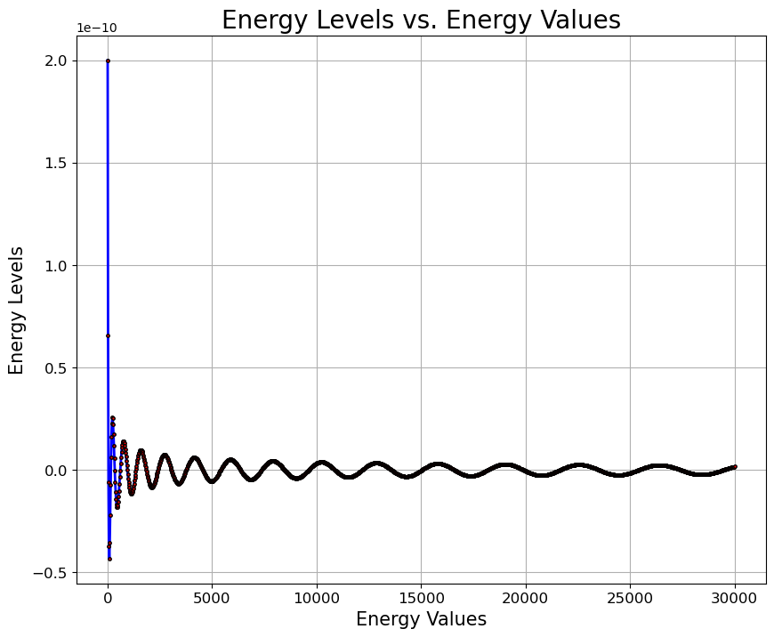

```
Lowest Energy Level: <pandas.io.formats.style.Styler object at 0x7fa61972c370>
```

```python
# calculate the potential energy of x points
V_pot0 = potential_energy(x_points)

# calculate the energy levels and associated energies
Energy_guess = energy_calculator(energy_array_I, frame_levels_I, energy_values_I, V_pot0)

# plot energy levels as a function of energy values
plt.figure(figsize=(10,8))
plt.plot(energy_values_I, Energy_guess[1], color='blue', linewidth=2, marker='.', markersize=5, markerfacecolor='red', markeredgecolor='black')
plt.xlabel('Energy Values', fontsize=15)
plt.ylabel('Energy Levels', fontsize=15)
plt.xticks(fontsize=12)
plt.yticks(fontsize=12)
plt.title('Energy Levels vs. Energy Values', fontsize=20)
plt.grid(True)
plt.show()

# print the lowest energy level
print(f"Lowest Energy Level: {Energy_guess[0]}")
```

## 3.2 Finding the ground state wavefunction and ascociated energies

```python
#old block:0.2

# Theoretical ground state energy
E = ((np.pi**2)*(h_bar**2))/(2*m_electron*(2*half_width)**2)
# Finding the energy solution for the ground state
En2 = secant(r,RungeKutta3d,1,V_pot0,Energy_guess[2],energy_values_I)
# # Conversion to eV
Energy_sol1 = En2/q_electron
#eV from joules
E_Eigenvalue = E/q_electron
# deltaE
delE = abs(E_Eigenvalue-Energy_sol1)

# Printing the results:
print('Preliminary energy readings')
print("Ground state energy:",Energy_sol1,"eV")
print("Energy at n=1   \n defined by: \n E-ground = {0:n} eV \
\n    \n   \n \
Delta E = {1:n} eV".format(E_Eigenvalue,delE))
```

```
Preliminary energy readings
Ground state energy: 37.603032633841515 eV
Energy at n=1
 defined by:
 E-ground = 37.603 eV


 Delta E = 1.64203e-05 eV
```

```python
#calculation of the ground state wavefunction with rungekitta

3
#non normalised solution
solution_wavefunction_NN = RungeKutta3d(r,x_points,h_step,solve_schrodinger_eq,En2,V_pot0)
```

```python
solution_wavefunction_N = normalize_wavefunction(solution_wavefunction_NN[0]) # Normalising the wavefunction for the ground state

sol2 = (1/np.sqrt(half_width))*np.cos((1*np.pi*x_points)/(2*half_width)) #analytical solution
```

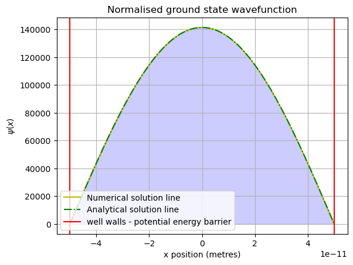

```python
#producing plot --> NORMALISED


plt.figure()
plt.plot(x_points2, solution_wavefunction_N, '-', label="Numerical solution line", color='y')  # Plotting normalised numeric wavefunction solution
plt.plot(x_points, sol2, '-.', label="Analytical solution line", color='g')  # Plotting the analytical solution
# marking the walls of the system (-> 'You may wish to represent the walls of the infinite square well potential on the plot as well)'
plt.axvline(x=x_start, c='r', label="well walls - potential energy barrier")
plt.axvline(x=x_end, c='r')
# Shade under the curve
plt.fill_between(x_points2, solution_wavefunction_N, 0, alpha=0.2, color='b')
# Add grid lines
plt.grid(True)
# Plot formatting
plt.legend(loc="lower left")
plt.title("Normalised ground state wavefunction")
plt.xlabel("x position (metres)")
plt.ylabel("$\psi(x)$")
```

### Matching numerical and analytical solutions

As expected we see that we have an excellend matech between out numerical and analytical solutions. This is a good indication that we are on the right track.

In quantum mechanics, wave-functions describe probability amplitudes of finding a particle at some particular position. Wave functions are mathematical functions that satisfy the Schrödinger equation. They can be calculated analytically or numerically for certain systems.

The Schrödinger equation's analytical wave function can be stated in a closed form, usually using well-known mathematical functions. For instance, depending on the boundary conditions, the analytical wave function for a particle in a one-dimensional infinite potential well is either a sine or a cosine function.

The numerical wave function, on the other hand; is computed numerically using computing techniques.The Runge Kutta method (can be found in functions) is used in the code you gave to solve the time-independent Schrödinger equation for a given potential to produce the numerical wave function.

The normalisation of the wave function is very important as it ensures that the summed total probability of finding the particle in all possible positions is equal to 1(in out case this means all possible x values). This means that the wave function has a well-defined probability density, and it can be used to calculate the probability of finding the particle in a certain region of space. In the code above, the normalisation of the numerical wave function is done using the normalisation() function, calculating the L2 norm of the wave function and scales it such that its integral over all space is equal to 1.

```python
well_class1 = "Infinite"  #setting well type to infinite for loop in energy_finder1() function
energy_values = energy_finder1(frame_levels_I, V_pot0, Energy_guess[2],energy_values_I, well_class1)
```

# 3.3 Finding the higher energy states

```python
energy_values[0]
```

Pandas dataframe showing energy values output from energy_finder1() function

| N(level) | Predicted / eV | Calculated (eV) | Difference (eV) |
| --- | --- | --- | --- |
| 1.000000 | 37.603016 | 37.603033 | 0.000016 |
| 2.000000 | 150.412065 | 150.412174 | 0.000109 |
| 3.000000 | 338.427146 | 338.424993 | 0.002153 |
| 4.000000 | 601.648259 | 601.670089 | 0.021830 |
| 5.000000 | 940.075405 | 940.069721 | 0.005685 |
| 6.000000 | 1353.708584 | 1353.695293 | 0.013290 |
| 7.000000 | 1842.547794 | 1842.520480 | 0.027314 |
| 8.000000 | 2406.593038 | 2406.556378 | 0.036660 |
| 9.000000 | 3045.844313 | 3045.792129 | 0.052185 |
| 10.000000 | 3760.301621 | 3760.261845 | 0.039777 |
| 11.000000 | 4549.964962 | 4549.882967 | 0.081995 |
| 12.000000 | 5414.834335 | 5414.743437 | 0.090897 |
| 13.000000 | 6354.909740 | 6354.790926 | 0.118814 |
| 14.000000 | 7370.191178 | 7370.011661 | 0.179516 |
| 15.000000 | 8460.678648 | 8460.517228 | 0.161420 |
| 16.000000 | 9626.372151 | 9626.205720 | 0.166430 |
| 17.000000 | 10867.271686 | 10866.880009 | 0.391677 |
| 18.000000 | 12183.377253 | 12183.077468 | 0.299785 |
| 19.000000 | 13574.688853 | 13574.198675 | 0.490178 |
| 20.000000 | 15041.206485 | 15040.708346 | 0.498139 |
| 21.000000 | 16582.930150 | 16582.349400 | 0.580750 |
| 22.000000 | 18199.859847 | 18199.081798 | 0.778050 |
| 23.000000 | 19891.995577 | 19891.352705 | 0.642872 |
| 24.000000 | 21659.337339 | 21658.181123 | 1.156216 |
| 25.000000 | 23501.885133 | 23500.587416 | 1.297717 |
| 26.000000 | 25419.638960 | 25417.990691 | 1.648270 |
| 27.000000 | 27412.598820 | 27411.237038 | 1.361782 |
| 28.000000 | 29480.764711 | 29478.497535 | 2.267177 |

```python
#PLOTTING FURTHER NORMALISED WAVEFUNCTIONS
```

# FIRST FEW EXCITED STATES

Below we can see the plots for the wavefunction for the first 5 energy states. Note that these wavefunctions have already been normalised using the normalisation() function. As shown in the legend 2 solutions for the wavefunciton: numerical and analytical have been plotted.

```python
Energy_sols = energy_values[1] # Setting a variable equal to the energy solutions
```

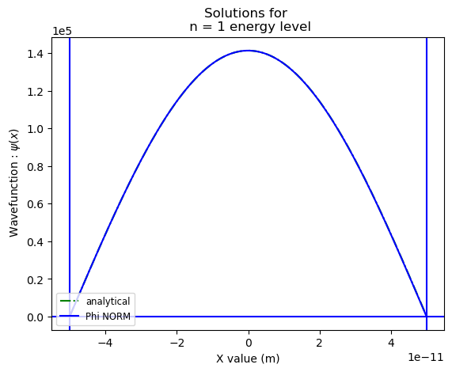

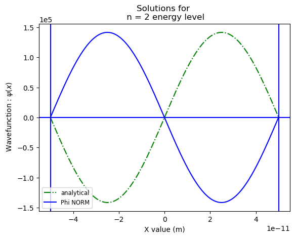

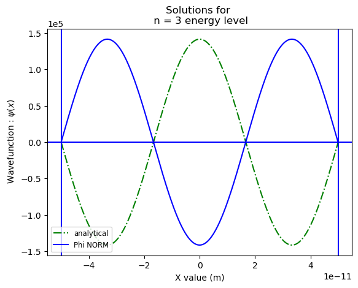

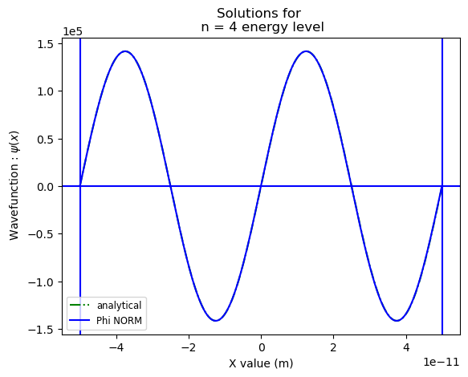

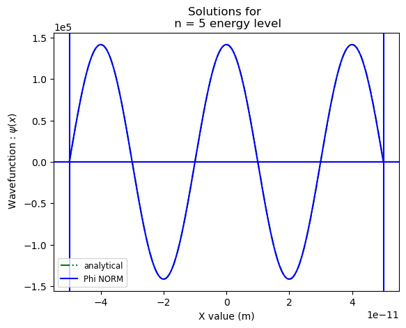

```python
# Create the first plot
plt.figure()
calcplot(Energy_sols[0], x_points2, 1, V_pot0, well_class1)
plt.title("Solutions for \n n = 1 energy level")
plt.show()


# Create the second plot
plt.figure()
calcplot(Energy_sols[1], x_points2, 2, V_pot0, well_class1)
plt.title("Solutions for \n n = 2 energy level")
plt.show()

# Create the third plot
plt.figure()
calcplot(Energy_sols[2], x_points2, 3, V_pot0, well_class1)
plt.title("Solutions for \n n = 3 energy level")
plt.show()

# Create the fourth plot
plt.figure()
calcplot(Energy_sols[3], x_points2, 4, V_pot0, well_class1)
plt.title("Solutions for \n n = 4 energy level")
plt.show()

# Create the fifth plot
plt.figure()
calcplot(Energy_sols[4], x_points2, 5, V_pot0, well_class1)
plt.title("Solutions for \n n = 5 energy level")
plt.show()
```

# Symmetry of the wavefunctions

Note that the analytical and numeric solutions to the wavefunctions are either: a.) Perfectly alligened or Symmetric or b.) oppite, reflected or Antisymmetric

This is not a mistake in our method but rather an intrinsic property of the wavefunction. Because of the characteristics of the potential well that they describe, wave functions can have either odd or even symmetry. Particularly, depending on whether the particle it describes is a boson or a fermion, the wave function must also be symmetric or antisymmetric for symmetric potential wells (i.e., potential wells that are identical on each side of the centre).

The wave function must also be symmetric or antisymmetric around the centre, as is the case, for instance, in the infinite square well, where the potential is symmetric about the well's centre. This indicates that the wave function is either oddly symmetric (i.e., it changes when reflected around the well's centre) or evenly symmetric. (i.e., it changes sign when reflected about the center of the well).

The requirement for odd or even symmetry arises from the boundary conditions imposed on the wave function at the edges of the potential well. These boundary conditions dictate that the wave function must be continuous and differentiable at the edges of the well, and this in turn leads to the requirement for odd or even symmetry.

# HIGHER ENERGY STATES

Does your method also work to find eigenstates for large n? Check this explicitly for at least two states in the range 18 ≤ n ≤ 28.

## plotting higher energy states

[output not shown]

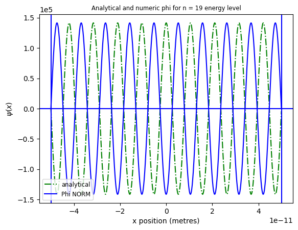

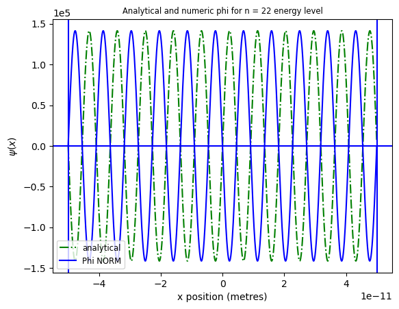

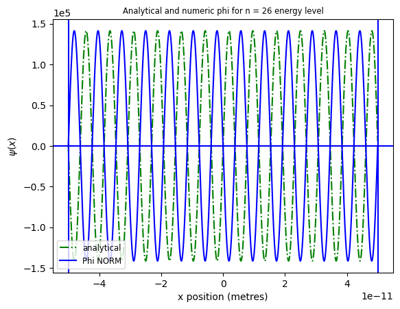

```python
#Checking that the code works for states in the range specified
#Checking for n=19, n=22, n=26

# Plot 1
fig, ax = plt.subplots()
calcplot(Energy_sols[18],x_points2,19,V_pot0,well_class1)
ax.set_title("Analytical and numeric phi for n = 19 energy level", fontsize='small')
ax.set_xlabel("x position (metres)")
ax.set_ylabel("$\psi(x)$")

# Plot 2
fig, ax = plt.subplots()
calcplot(Energy_sols[21],x_points2,22,V_pot0,well_class1)
ax.set_title("Analytical and numeric phi for n = 22 energy level", fontsize='small')
ax.set_xlabel("x position (metres)")
ax.set_ylabel("$\psi(x)$")

# Plot 3
fig, ax = plt.subplots()
calcplot(Energy_sols[25],x_points2,26,V_pot0,well_class1)
ax.set_title("Analytical and numeric phi for n = 26 energy level", fontsize='small')
ax.set_xlabel("x position (metres)")
ax.set_ylabel("$\psi(x)$")
'''

plt.subplot(grid[1,1])
calcplotplotter(Energy_sols[27],x_points2,28,V_pot0,well_class1)
plt.title("Numerical Wavefunction \n against theoretical wavefunction for \n n = 28 energy level", fontsize = 'small');

'''
```

### Eigenstates for large values of n:

As we can see, our method is also successfull at finding eigenstates for larger values of n in the range : 18 ≤ n ≤ 28.